# Group Project 7– Jayne, Olivia, Sarah

Biology 368/664 Bucknell University

Prof. Ken Field

9 Feb 2022

## R for Cancer Biology!

Welcome to this R tutorial for upper level biology students interested in cancer biology! This tutorial is designed for someone who has had some experience with R, but not much.

While all of the code chunks are here in this tutorial, if you want to add more simply click on the “+C” button at the top and select “R”. If you want to make comments within a code chunk (in addition to comments like this, in the white space), you can use a “#” before writing a few words. For example: function() #Comment

First thing’s first, let’s load in the necessary packages to run the code we are going to need for this tutorial. While R has many built in functions, sometimes we need to add in packages to run more advanced code. If you need to add more packages during a project, it is easiest to add it into the code chunk below in the same format.

## Introduction and Loading in Data

For this tutorial, we will explore the TARGET neuroblastoma data to gain insights about genetics and risk factors related to neuroblastoma. Neuroblastoma is the most common extracranial solid cancer in children. The 5 year survival rate has increased to ~50% with recent developments in immunotherapy and other novel treatments but this statistic begs the need for additional research and analysis. One way to gain insights that might be translatable to the clinic is delving into patient data to uncover important patterns that might point towards ways to refine precision medicine approaches for neuroblastoma (Matthay, 2016).

MYCN is an important oncogene in neuroblastoma. Focal amplification of MYCN is seen in some of the most aggressive cases and amplification marks 20-30% of total cases. MYCN status is a binary response variable in this dataset that can be explored.

First, we need to read in the TARGET neuroblastoma data. White space in the dataframe was removed using the “trim_ws” code. You can first assess the success of the data import by looking at the first 6 rows of the dataframe using the “head()” function. The structure of the dataframe was assessed using the “str()” function. This informs us about the coding of each column and the contents of each column (e.g. there is a gender variable and the data is coded as a character).

```r
neuroblastoma <- read_csv("neuroblastoma.csv", trim_ws = TRUE)
head(neuroblastoma)
str(neuroblastoma)
```

[output not shown]

[output not shown]

| TARGET_USI | Gender | Race | Ethnicity | Age_Diagnosis | First Event | Event Free Survival Time in Days | Vital_Status | Overall_Survival_Time_in_Days | Year of Diagnosis | Year of Last Follow Up | Protocol | INSS Stage | MYCN | Ploidy | Ploidy Value | Histology | Grade | MKI | Diagnostic_Category | ICDO | ICDO Description | COG_Risk_Group | Percent Tumor | Percent Necrosis | Percent Tumor v/s Stroma | Sites of Disease Involvement | Site Relapse | Relapse Percent Tumor | Relapse Percent Necrosis | … |
| --- | --- | --- | --- | --- | --- | --- | --- | --- | --- | --- | --- | --- | --- | --- | --- | --- | --- | --- | --- | --- | --- | --- | --- | --- | --- | --- | --- | --- | --- | --- |
| TARGET-30-PAAPFA | Male | White | Not Hispanic or Latino | 1762 | Event | 444 | Dead | 487 | 1986 | 1988 | I03, 321P2, E04, 321P3, B954 | Stage 4 | Not Amplified | Unknown | NA | Unfavorable | Unknown | Unknown | Unknown | Unknown | Unknown | High Risk | NA | NA | NA | NA | NA | NA | NA | … |
| TARGET-30-PACLJN | Male | White | Not Hispanic or Latino | 1475 | Censored | 5550 | Alive | 5550 | 1986 | 2001 | 323P, 321P3, I03, B954 | Stage 4 | Not Amplified | Unknown | NA | Unknown | Unknown | Unknown | Unknown | Unknown | Unknown | High Risk | NA | NA | NA | NA | NA | NA | NA | … |
| TARGET-30-PACPJG | Female | White | Not Hispanic or Latino | 760 | Unknown | NA | Unknown | NA | 1987 | NA | 323P, B954 | Unknown | Unknown | Unknown | NA | Unknown | Unknown | Unknown | Unknown | Unknown | Unknown | Unknown | NA | NA | NA | NA | NA | NA | NA | … |
| TARGET-30-PACRYY | Male | Unknown | Hispanic or Latino | 1314 | Censored | 5296 | Alive | 5296 | 1987 | 2002 | 321P3, I03, S31 | Stage 4 | Not Amplified | Unknown | NA | Unfavorable | Unknown | Unknown | Unknown | Unknown | Lge Right retroperitoneal mass extending thru into the lesser sac beneath the porta hepatis. Was encapsulated in RUQ with periaortic nodes | High Risk | NA | NA | NA | NA | NA | NA | NA | … |
| TARGET-30-PACRZM | Male | White | Not Hispanic or Latino | 3686 | Event | 922 | Dead | 922 | 1987 | 1990 | 321P2 | Stage 4 | Not Amplified | Unknown | NA | Unfavorable | Unknown | Unknown | Unknown | Unknown | Unknown | High Risk | NA | NA | NA | NA | NA | NA | NA | … |
| TARGET-30-PACSNL | Female | White | Not Hispanic or Latino | 2157 | Event | 205 | Dead | 322 | 1988 | 1989 | 321P2, B003, S31, B954 | Stage 4 | Not Amplified | Unknown | NA | Unfavorable | Unknown | Unknown | Unknown | Unknown | Metastatic NBL | High Risk | NA | NA | NA | NA | NA | NA | NA | … |

It’s time to clean up the data. Work in R is A LOT easier when you are working with a clean and filtered dataframe. Once we have explored the data and decide what questions are good questions to ask, we will remove irrelevant columns or filter by rows that include certain responses. For now, we see that there is a diagnosis category variable. We can use the “table()” function by specifying the data set and variable to see all recorded responses for diagnostic category. The majority of the responses are for neuroblastoma, which is the diagnosis type we are interested in, while 157 patients had unknown or ganglioneuroblastoma diagnoses. We will filter our dataset, creating a new one (NBOnly) that only includes neuroblastoma diagnoses. We can check the success of the filter by using the head() function again and can make sure that the number of rows (using nrows()) matches the number of pateints that we found had that diagnosis when we applied the table() function. 463! That checks out.

```r
table(neuroblastoma$Diagnostic_Category)
NBOnly<-filter(neuroblastoma, Diagnostic_Category=="Neuroblastoma")
head(NBOnly)
nrow(NBOnly)
```

```
Ganglioneuroblastoma, intermixed    Ganglioneuroblastoma, nodular                    Neuroblastoma                          Unknown
                               4                               77                              463                               76
```

```
[1] 463
```

| TARGET_USI | Gender | Race | Ethnicity | Age_Diagnosis | First Event | Event Free Survival Time in Days | Vital_Status | Overall_Survival_Time_in_Days | Year of Diagnosis | Year of Last Follow Up | Protocol | INSS Stage | MYCN | Ploidy | Ploidy Value | Histology | Grade | MKI | Diagnostic_Category | ICDO | ICDO Description | COG_Risk_Group | Percent Tumor | Percent Necrosis | Percent Tumor v/s Stroma | Sites of Disease Involvement | Site Relapse | Relapse Percent Tumor | Relapse Percent Necrosis | … |
| --- | --- | --- | --- | --- | --- | --- | --- | --- | --- | --- | --- | --- | --- | --- | --- | --- | --- | --- | --- | --- | --- | --- | --- | --- | --- | --- | --- | --- | --- | --- |
| TARGET-30-PADFLI | Male | White | Not Hispanic or Latino | 557 | Censored | 2872 | Alive | 2872 | 1991 | 1999 | 3891, B003, B954 | Stage 4 | Not Amplified | Unknown | NA | Unfavorable | Undifferentiated or Poorly Differentiated | High | Neuroblastoma | Unknown | Shimada: unfavorable; NMYC: < 10 copies; Serum ferritin ND; Abd adrenal- 13 cm-Right sided retroperitoneal mass-crossing the midline; no intraspinal extn. | High Risk | NA | NA | NA | NA | NA | NA | NA | … |
| TARGET-30-PADIHC | Male | White | Not Hispanic or Latino | 1916 | Event | 165 | Alive | 4596 | 1992 | 2005 | 3891, B003, 0914, E18 | Stage 4 | Not Amplified | Unknown | NA | Unfavorable | Undifferentiated or Poorly Differentiated | Low | Neuroblastoma | Unknown | Retroperitoneal abdominal adrenal Right side extends across midline-no intraspinal ext.-10x12x8cm. Mets to BM/Bone/LN | High Risk | NA | NA | NA | NA | NA | NA | NA | … |
| TARGET-30-PADINC | Male | Black or African American | Not Hispanic or Latino | 1004 | Event | 252 | Dead | 409 | 1992 | 1993 | 3891, B003, B954, E18 | Stage 4 | Amplified | Unknown | NA | Unfavorable | Undifferentiated or Poorly Differentiated | Low | Neuroblastoma | Unknown | Left retroperitoneal mass-no intraspinal ext-7x5x5cm-Bone/BM mets | High Risk | NA | NA | NA | NA | NA | NA | NA | … |
| TARGET-30-PADIRB | Female | Unknown | Not Hispanic or Latino | 1191 | Event | 798 | Alive | 3855 | 1992 | 2003 | 3891, B003, B954, E18 | Stage 4 | Not Amplified | Unknown | NA | Unfavorable | Undifferentiated or Poorly Differentiated | Low | Neuroblastoma | Unknown | Right sided Abdominal adrenal tumor -no intraspinal ext.-6.5x5.5x5.5cm - Bone/BM mets | High Risk | NA | NA | NA | NA | NA | NA | NA | … |
| TARGET-30-PADKGF | Male | White | Not Hispanic or Latino | 554 | Censored | 2644 | Alive | 2644 | 1992 | 2000 | 3891, B003, B954, E18 | Stage 4 | Not Amplified | Unknown | NA | Unfavorable | Undifferentiated or Poorly Differentiated | High | Neuroblastoma | Unknown | Retroperitoneal abdominal celiac mass crossing the midline involvement of mesentery-no intraspinal ext.-8x9x12cm-Mets; LN/BM | High Risk | NA | NA | NA | NA | NA | NA | NA | … |
| TARGET-30-PADKNE | Female | White | Not Hispanic or Latino | 1748 | Event | 387 | Dead | 588 | 1993 | 1994 | 3891, B003, 0925, B954, R9702, E18 | Stage 4 | Amplified | Unknown | NA | Unfavorable | Undifferentiated or Poorly Differentiated | High | Neuroblastoma | C74.9 | Adrenal gland, NOS Suprarenal gland Adrenal, NOS | High Risk | NA | NA | NA | NA | NA | NA | NA | … |

Upon looking att he different variables included in the TARGET data, there are several variables that we have identified as being useful for looking at several select questions about neuroblastoma. Here are a few that we will look at further:

1. Does MYCN amplification have a significant effect on the survival of neuroblastoma patients?
2. Is the length of survival after diagnosis for patients that died significantly different when MYCN is amplified vs. non amplified (Is survival time less with MYCN amplification?)?
3. For patients who died, does patient age at diagnosis correlate with the number of days they survived after diagnosis?
4. Do patients above and below the median age of diagnosis (18 mo) have different survival rates?

Given those initial questions, the only variables in the dataframe we require for our continued analysis are: MYCN, Age_Diagnosis, Vital_status, Diagnostic_category, and Overall_survival_Time_in_Days. We will remove the rest of the columns that are no longer relevant, and will keep the Target_USI (patient ID) for easy reference by other scientists if necessary.

```r
NBOnly <- dplyr::select(NBOnly, c(MYCN, Age_Diagnosis, Vital_Status, Diagnostic_Category, Overall_Survival_Time_in_Days, TARGET_USI)) #Filter data for only necessary variables
NBOnly <- as.data.frame(NBOnly) #Make it a data frame
NBOnly <- filter(NBOnly, MYCN=="Amplified" | MYCN=="Not Amplified")  #remove "Unknwon" level for MYCN status
head(NBOnly)
str(NBOnly)
table(NBOnly$MYCN)
```

```
'data.frame':   456 obs. of  6 variables:
 $ MYCN                         : chr  \Not Amplified\ \Not Amplified\ \Amplified\ \Not Amplified\ ...
 $ Age_Diagnosis                : num  557 1916 1004 1191 554 ...
 $ Vital_Status                 : chr  \Alive\ \Alive\ \Dead\ \Alive\ ...
 $ Diagnostic_Category          : chr  \Neuroblastoma\ \Neuroblastoma\ \Neuroblastoma\ \Neuroblastoma\ ...
 $ Overall_Survival_Time_in_Days: num  2872 4596 409 3855 2644 ...
 $ TARGET_USI                   : chr  \TARGET-30-PADFLI\ \TARGET-30-PADIHC\ \TARGET-30-PADINC\ \TARGET-30-PADIRB\ ...
```

```
    Amplified Not Amplified
          155           301
```

|  | MYCN | Age_Diagnosis | Vital_Status | Diagnostic_Category | Overall_Survival_Time_in_Days | TARGET_USI |
| --- | --- | --- | --- | --- | --- | --- |
| 1 | Not Amplified | 557 | Alive | Neuroblastoma | 2872 | TARGET-30-PADFLI |
| 2 | Not Amplified | 1916 | Alive | Neuroblastoma | 4596 | TARGET-30-PADIHC |
| 3 | Amplified | 1004 | Dead | Neuroblastoma | 409 | TARGET-30-PADINC |
| 4 | Not Amplified | 1191 | Alive | Neuroblastoma | 3855 | TARGET-30-PADIRB |
| 5 | Not Amplified | 554 | Alive | Neuroblastoma | 2644 | TARGET-30-PADKGF |
| 6 | Amplified | 1748 | Dead | Neuroblastoma | 588 | TARGET-30-PADKNE |

Using the structure function, we saw that some variables are coded as characters but would serve us better coded as factors. The variables that have repeating responses–levels–and not all unique responses are the ones we would like to code as factors now. For example, MYCN has two different possible responses: amplified and not amplified– there are two MYCN status levels. We see this updated when we rerun the str() function

```r
NBOnly$Diagnostic_Category <- as.factor(NBOnly$Diagnostic_Category)
NBOnly$Vital_Status <- as.factor(NBOnly$Vital_Status)
NBOnly$MYCN <- as.factor(NBOnly$MYCN)
str(NBOnly)
```

```
'data.frame':   456 obs. of  6 variables:
 $ MYCN                         : Factor w/ 2 levels \Amplified\,\Not Amplified\: 2 2 1 2 2 1 2 1 1 2 ...
 $ Age_Diagnosis                : num  557 1916 1004 1191 554 ...
 $ Vital_Status                 : Factor w/ 2 levels \Alive\,\Dead\: 1 1 2 1 1 2 2 2 2 2 ...
 $ Diagnostic_Category          : Factor w/ 1 level \Neuroblastoma\: 1 1 1 1 1 1 1 1 1 1 ...
 $ Overall_Survival_Time_in_Days: num  2872 4596 409 3855 2644 ...
 $ TARGET_USI                   : chr  \TARGET-30-PADFLI\ \TARGET-30-PADIHC\ \TARGET-30-PADINC\ \TARGET-30-PADIRB\ ...
```

**(1) Does MYCN amplification have a significant effect on the survival of neuroblastoma patients?**

Considering question 1, we would like to see information about the vital status of patients with MYCN amplification and patients without MYCN amplification separately. Like was done before, we can use the filter() function to create subsets of the neuroblastoma dataframe to only include one genetic status or the other. We then validated that these codes were carried out correctly by scanning the head of each subset to ensure the MYCN variable only includes the specified MYCN status response.

```r
amp<- filter(NBOnly, MYCN=="Amplified") #Creating subest of data called amp (only includes Amplified MYCN)
amp <- as.data.frame(amp) #Making amp subset of data it's own data frame
nonamp<- filter(NBOnly, MYCN=="Not Amplified") #Creating subset of data called nonamp (only includes Not Amplified MYCN)
nonamp <- as.data.frame(nonamp) #Making nonamp subset of data it's own data frame
head(amp)
head(nonamp)
```

|  | MYCN | Age_Diagnosis | Vital_Status | Diagnostic_Category | Overall_Survival_Time_in_Days | TARGET_USI |
| --- | --- | --- | --- | --- | --- | --- |
| 1 | Amplified | 1004 | Dead | Neuroblastoma | 409 | TARGET-30-PADINC |
| 2 | Amplified | 1748 | Dead | Neuroblastoma | 588 | TARGET-30-PADKNE |
| 3 | Amplified | 648 | Dead | Neuroblastoma | 341 | TARGET-30-PADKXS |
| 4 | Amplified | 1723 | Dead | Neuroblastoma | 1083 | TARGET-30-PADKYP |
| 5 | Amplified | 805 | Dead | Neuroblastoma | 13 | TARGET-30-PADLDT |
| 6 | Amplified | 780 | Alive | Neuroblastoma | 1749 | TARGET-30-PADLKJ |

|  | MYCN | Age_Diagnosis | Vital_Status | Diagnostic_Category | Overall_Survival_Time_in_Days | TARGET_USI |
| --- | --- | --- | --- | --- | --- | --- |
| 1 | Not Amplified | 557 | Alive | Neuroblastoma | 2872 | TARGET-30-PADFLI |
| 2 | Not Amplified | 1916 | Alive | Neuroblastoma | 4596 | TARGET-30-PADIHC |
| 3 | Not Amplified | 1191 | Alive | Neuroblastoma | 3855 | TARGET-30-PADIRB |
| 4 | Not Amplified | 554 | Alive | Neuroblastoma | 2644 | TARGET-30-PADKGF |
| 5 | Not Amplified | 1426 | Dead | Neuroblastoma | 621 | TARGET-30-PADKRU |
| 6 | Not Amplified | 4594 | Dead | Neuroblastoma | 791 | TARGET-30-PADLDA |

In exploring this question, we can now use these subsets for MYCN status to see how many patients had died or remained alive at the time of patient data collection. Looking at the frequency of death for each subset of MYCN status, we see preliminarily that more patients died than survived who had MYCN amplification, and the reverse was true for MYCN nonamplified patients.

```r
table(amp$Vital_Status)
table(nonamp$Vital_Status)
```

```
Alive  Dead
   62    93
```

```
Alive  Dead
  166   135
```

Based on the table, it appears that patients with Amplified MYCN have a higher proportion of individuals who died than patients with Not Amplified MYCN.

Now that we have explored and filtered the data, we should visualize the data before testing our hypotheses.

To visualize how MYCN amplification relates to survival of neuroblastoma patients, we can make a bar plot to compare the two groups using ggplot().

Within ggplot(), we first want to indicate the data frame we are pulling information from. It then takes the argument aes(x=,y=) where we can add our x and y variables and geom_bar() to indicate that we want our data to be displayed as a bar graph. We also want to add stat=“identity” so the bar graph gives us counts of “Alive vs Dead” patients within each group. Within the aes(), we can also add “fill=Vital_Status” so each bar in our graph has a different color to indicate dead vs alive patients.

Using ggtitle() gives our plot a title and xlab() and ylab() to label the x and y axes (although we don’t need to relabel the x-axis in this case). In addition, we have added the function theme_cowplot() that we can add to all of our plots to give them a consistent and clean theme.

Adding a “+” between each function links them together to make a graph that follows all of our requests.

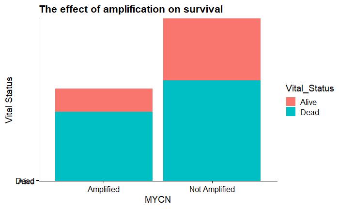

To test whether MYCN amplification has a significant effect on the survival of neuroblastoma patients we want to compare whether or not MYCN was amplified compared to whether or not that patient survived. We want to test to see whether or not the two variables are independent of one another which we can do with a chi-squared test. To run this test, we can create a table that contains the two variables of interest (MYCN amplification and their vital status). We can then run a chi squared test using the “chisq.test()” function.

The null hypothesis we are testing is that the two variables are independent of one another.

```r
amp.chitest <- NBOnly
amp.chitest$MYCN <- factor(amp.chitest$MYCN)
amp.chitest <- table(amp.chitest$MYCN, amp.chitest$Vital_Status)
amp.chitest
chisq.test(amp.chitest)
```

```
                Alive Dead
  Amplified        62   93
  Not Amplified   166  135
```

```
    Pearson's Chi-squared test with Yates' continuity correction

data:  amp.chitest
X-squared = 8.7965, df = 1, p-value = 0.003018
```

As we can see from the ouput above, we get a X-squared value of 8.7965 and a p-value that is much less than 0.05 which means that we reject the null hypothesis and can see that the two variables are in fact dependent on one another!

**(2) Is the length of survival after diagnosis for patients that died significantly different when MYCN is amplified vs. non amplified (Is survival time less with MYCN amplification?)?**

Here we filtered the dataframe to only include patients that died. In this question we will be assessing a putative relationship between MYCN amplification and the amount of days of survival after diagnosis to possibly gain insights about if the lethality of MYCN amplification is more aggressive/ quicker than non amplified cases. We excluded patients that were alive because the amount of days of survival after diagnosis is not an informative number for this question because the number of days would depend arbitrarily on when the data happened to be collected. We ordered the number of days of survival for patients that had dead from lowest to highest and looked at the patients with the patients with the 25 shortest survival times and the 25 longest survival times. With this arrangement we were able to see that the top 25 shortest survival times had more patients that had MYCN amplification while the 25 longest survival times had more MYCN nonamplified patients.

```r
dead<- filter(NBOnly, Vital_Status=="Dead")
dead <- as.data.frame(dead)
head(dead)
DeadOrder<- arrange(dead, Overall_Survival_Time_in_Days)
head(DeadOrder, 25)
tail(DeadOrder, 25)
```

```r
dead<- filter(NBOnly, Vital_Status=="Dead")
dead <- as.data.frame(dead)
head(dead)
```

|  | MYCN | Age_Diagnosis | Vital_Status | Diagnostic_Category | Overall_Survival_Time_in_Days | TARGET_USI |
| --- | --- | --- | --- | --- | --- | --- |
| 1 | Amplified | 1004 | Dead | Neuroblastoma | 409 | TARGET-30-PADINC |
| 2 | Amplified | 1748 | Dead | Neuroblastoma | 588 | TARGET-30-PADKNE |
| 3 | Not Amplified | 1426 | Dead | Neuroblastoma | 621 | TARGET-30-PADKRU |
| 4 | Amplified | 648 | Dead | Neuroblastoma | 341 | TARGET-30-PADKXS |
| 5 | Amplified | 1723 | Dead | Neuroblastoma | 1083 | TARGET-30-PADKYP |
| 6 | Not Amplified | 4594 | Dead | Neuroblastoma | 791 | TARGET-30-PADLDA |

```r
DeadOrder<- arrange(dead, Overall_Survival_Time_in_Days)
head(DeadOrder, 25)
```

|  | MYCN | Age_Diagnosis | Vital_Status | Diagnostic_Category | Overall_Survival_Time_in_Days | TARGET_USI |
| --- | --- | --- | --- | --- | --- | --- |
| 1 | Not Amplified | 31 | Dead | Neuroblastoma | 8 | TARGET-30-PASZKE |
| 2 | Amplified | 805 | Dead | Neuroblastoma | 13 | TARGET-30-PADLDT |
| 3 | Not Amplified | 4 | Dead | Neuroblastoma | 20 | TARGET-30-PASUML |
| 4 | Not Amplified | 663 | Dead | Neuroblastoma | 22 | TARGET-30-PAMVAG |
| 5 | Amplified | 890 | Dead | Neuroblastoma | 24 | TARGET-30-PAPHGF |
| 6 | Amplified | 611 | Dead | Neuroblastoma | 26 | TARGET-30-PAPGJR |
| 7 | Amplified | 605 | Dead | Neuroblastoma | 34 | TARGET-30-PAIEFC |
| 8 | Amplified | 860 | Dead | Neuroblastoma | 38 | TARGET-30-PALJPX |
| 9 | Not Amplified | 551 | Dead | Neuroblastoma | 61 | TARGET-30-PANEYN |
| 10 | Not Amplified | 1643 | Dead | Neuroblastoma | 87 | TARGET-30-PAMLCS |

[output cut: 15 more lines]

```r
tail(DeadOrder, 25)
```

|  | MYCN | Age_Diagnosis | Vital_Status | Diagnostic_Category | Overall_Survival_Time_in_Days | TARGET_USI |
| --- | --- | --- | --- | --- | --- | --- |
| 204 | Not Amplified | 882 | Dead | Neuroblastoma | 1795 | TARGET-30-PAKGKH |
| 205 | Not Amplified | 1499 | Dead | Neuroblastoma | 1836 | TARGET-30-PAITRM |
| 206 | Not Amplified | 1555 | Dead | Neuroblastoma | 1836 | TARGET-30-PARFWB |
| 207 | Not Amplified | 1202 | Dead | Neuroblastoma | 1858 | TARGET-30-PAMRKH |
| 208 | Amplified | 656 | Dead | Neuroblastoma | 1912 | TARGET-30-PARJTB |
| 209 | Not Amplified | 1031 | Dead | Neuroblastoma | 1933 | TARGET-30-PANUVK |
| 210 | Not Amplified | 1319 | Dead | Neuroblastoma | 2002 | TARGET-30-PASCJJ |
| 211 | Not Amplified | 3625 | Dead | Neuroblastoma | 2039 | TARGET-30-PARBGP |
| 212 | Amplified | 573 | Dead | Neuroblastoma | 2056 | TARGET-30-PAPSEI |
| 213 | Not Amplified | 1157 | Dead | Neuroblastoma | 2103 | TARGET-30-PALPKZ |

[output cut: 15 more lines]

To visualize the relationship between MYCN amplification (a categorical variable) and length of survival (numerical variable), we can create a box plot using the function ggplot(). First we can create a basic box plot.

```r
basic_plot <- ggplot(dead) + #Tell ggplot what data frame you are working in
  aes(x =MYCN , y=Overall_Survival_Time_in_Days) + #Add x and y variables
  geom_boxplot() #Let ggplot know you want to create a boxplot
basic_plot
```

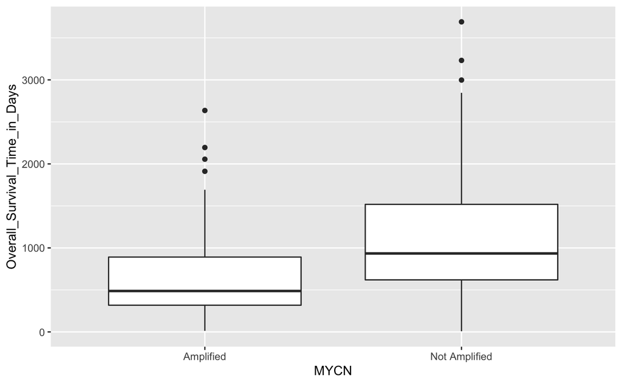

To make our plot even better, we can add all of our data points to the plot. It is always better to add your data to a plot because it is more transparent. We can add the function geom_jitter() to tell our plot to plot all the data points. You can make the width of the points whatever you want and we can also add the argument “alpha=” to make the points more transparent so we can see the boxplot behind all the data points.

We also added axis names and titles again.

```r
survival_plot <- ggplot(dead) +
  aes(x =MYCN , y=Overall_Survival_Time_in_Days) +
  geom_boxplot() +
  geom_jitter(width=.2, alpha=0.5) + #Adding our data points
  theme_cowplot() + #Adding cowplot theme
  ggtitle("MYCN Amplification Effect on Survival") +  #Title
  xlab("MYCN Amplification") + #x-axis title
  ylab("Overall Survival Time (days)") #y-axis title
survival_plot
```

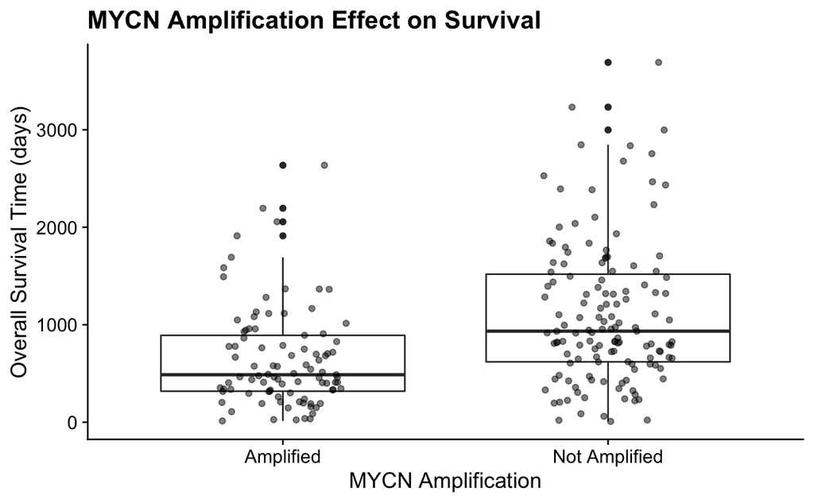

In addition to seeing that the Not Amplified median survival length is higher than Amplified median survival length, adding the data points allows us to see that we have more observations in the Not Amplified category than the Amplified category. This is consistent with what we would expect of a random sample since MYCN amplification only occurs in 20-30% of cases (Matthay, 2016).

The statistical test we want to use to determine if the length of survival after diagnosis for patients that died significantly different when MYCN is amplified vs. non amplified is an unpaired two way t-test.

```r
dead <- NBOnly
dead <- filter(dead, Vital_Status=="Dead")
dead$MYCN <- factor(dead$MYCN)
str(dead)
levels(dead$MYCN)
```

```
'data.frame':   228 obs. of  6 variables:
 $ MYCN                         : Factor w/ 2 levels \Amplified\,\Not Amplified\: 1 1 2 1 1 2 1 2 1 2 ...
 $ Age_Diagnosis                : num  1004 1748 1426 648 1723 ...
 $ Vital_Status                 : Factor w/ 2 levels \Alive\,\Dead\: 2 2 2 2 2 2 2 2 2 2 ...
 $ Diagnostic_Category          : Factor w/ 1 level \Neuroblastoma\: 1 1 1 1 1 1 1 1 1 1 ...
 $ Overall_Survival_Time_in_Days: num  409 588 621 341 1083 ...
 $ TARGET_USI                   : chr  \TARGET-30-PADINC\ \TARGET-30-PADKNE\ \TARGET-30-PADKRU\ \TARGET-30-PADKXS\ ...
```

```
[1] \Amplified\     \Not Amplified\
```

Once we have filtered the data we can run two shapiro tests to determine if the data is normally distributed.

```r
shapiro.test(dead$Overall_Survival_Time_in_Days[dead$MYCN=="Amplified"])
shapiro.test(dead$Overall_Survival_Time_in_Days[dead$MYCN=="Not Amplified"])
```

```
    Shapiro-Wilk normality test

data:  dead$Overall_Survival_Time_in_Days[dead$MYCN == \Amplified\]
W = 0.87588, p-value = 2.745e-07
```

```
    Shapiro-Wilk normality test

data:  dead$Overall_Survival_Time_in_Days[dead$MYCN == \Not Amplified\]
W = 0.93219, p-value = 4.214e-06
```

It appears that the data is not normally distributed since both p-values are less than 0.05, but since the sample sizes are large enough we can still proceed with running our t-test. To do this we run the function “t.test” where we are comparing overall survival time to MYCN amplification status.

**(3) For patients who died, does patient age at diagnosis correlate with the number of days they survived after diagnosis?**

To get a quick sense of this question, we can look at the numerical summary for the distribution of days of survival after diagnosis for patients who died. Once you run the first line of code you can see that the mean was about 930 days. The next step is to order the data from youngest patient diagnosed to oldest patient diagnosed. From there, we can look at the youngest 25 patients diagnosed and the oldest 25 patients diagnosed.

```r
summary(dead$Overall_Survival_Time_in_Days)
dead<-arrange(dead, Age_Diagnosis)
head(dead, 25)
tail(dead, 25)
```

```
   Min. 1st Qu.  Median    Mean 3rd Qu.    Max.
    8.0   414.5   787.0   925.0  1290.8  3691.0
```

|  | MYCN | Age_Diagnosis | Vital_Status | Diagnostic_Category | Overall_Survival_Time_in_Days | TARGET_USI |
| --- | --- | --- | --- | --- | --- | --- |
| 1 | Not Amplified | 4 | Dead | Neuroblastoma | 20 | TARGET-30-PASUML |
| 2 | Not Amplified | 31 | Dead | Neuroblastoma | 8 | TARGET-30-PASZKE |
| 3 | Not Amplified | 328 | Dead | Neuroblastoma | 481 | TARGET-30-PATYIL |
| 4 | Not Amplified | 341 | Dead | Neuroblastoma | 2466 | TARGET-30-PARHAM |
| 5 | Amplified | 406 | Dead | Neuroblastoma | 333 | TARGET-30-PASHFA |
| 6 | Amplified | 522 | Dead | Neuroblastoma | 682 | TARGET-30-PASJYB |
| 7 | Amplified | 549 | Dead | Neuroblastoma | 703 | TARGET-30-PAIUJB |
| 8 | Not Amplified | 551 | Dead | Neuroblastoma | 61 | TARGET-30-PANEYN |
| 9 | Amplified | 557 | Dead | Neuroblastoma | 237 | TARGET-30-PAPZWS |
| 10 | Amplified | 564 | Dead | Neuroblastoma | 1368 | TARGET-30-PAIXRK |

[output cut: 15 more lines]

|  | MYCN | Age_Diagnosis | Vital_Status | Diagnostic_Category | Overall_Survival_Time_in_Days | TARGET_USI |
| --- | --- | --- | --- | --- | --- | --- |
| 204 | Not Amplified | 1900 | Dead | Neuroblastoma | 1033 | TARGET-30-PASTCN |
| 205 | Amplified | 1942 | Dead | Neuroblastoma | 1116 | TARGET-30-PARDYU |
| 206 | Not Amplified | 1955 | Dead | Neuroblastoma | 1102 | TARGET-30-PAPUWY |
| 207 | Not Amplified | 1961 | Dead | Neuroblastoma | 1765 | TARGET-30-PAPVFD |
| 208 | Not Amplified | 1972 | Dead | Neuroblastoma | 1438 | TARGET-30-PASGPY |
| 209 | Not Amplified | 1978 | Dead | Neuroblastoma | 1540 | TARGET-30-PAMVLG |
| 210 | Not Amplified | 1996 | Dead | Neuroblastoma | 240 | TARGET-30-PADPCI |
| 211 | Amplified | 2008 | Dead | Neuroblastoma | 2636 | TARGET-30-PAPCTS |
| 212 | Not Amplified | 2178 | Dead | Neuroblastoma | 724 | TARGET-30-PARURB |
| 213 | Not Amplified | 2241 | Dead | Neuroblastoma | 1321 | TARGET-30-PARGKK |

[output cut: 15 more lines]

For the younger patients, most of the survival times were below the 930 day average, and for the older patients, most had survival times above 930 days. This leads us to a further analysis as to if younger patients have significantly lower life expectancies after a neuroblastoma diagnosis.

Since both variables in this question are numerical, we can create a linear model to visualize the relationship between age at diagnosis and length of survival after diagnosis again using ggplot().

```r
ggplot(data=dead, aes(x = Age_Diagnosis, y = Overall_Survival_Time_in_Days)) +
  geom_point(position = "jitter",size=0.05) + #Scatterplot
  scale_x_continuous(breaks = seq.int(0, 8000, 1000)) + #x-axis length
  geom_smooth(method='lm',se=FALSE) + #linear regression
  ggtitle('Age at Diagnosis and Survival Length') +
  xlab("Age at Diagnosis (days)") +
  ylab("Overall Survival Time (days)") +
  theme_cowplot()
```

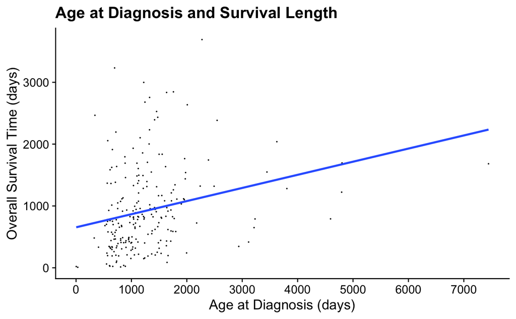

There does not appear to be a strong relationship. We can explore if a linear model fits the data later, when we do our hypothesis testing.

To compare how the patients age at diagnosis impacts their survival time we can run a linear model to see if the two variables are related to one another. A linear model is a useful function to run since it is able to run a t test comparing the two variables to one another. To use this function run the command, lm() where you want to see if one variable (in this case, overall survival time) is correlated to another variables (for us, age at diagnosis). To run a linear model we make a few assumptions including that the data is linear, the residuals are normal, the residuals have a constant variance, and each residual error is independent of one another. To test to see if those conditions are met we can plot our linear model and look at the graphs of the residuals and the Q-Q plot.

```r
age.death <- lm(Overall_Survival_Time_in_Days ~ Age_Diagnosis, data = dead)
summary(age.death)
plot(age.death)
```

```
Call:
lm(formula = Overall_Survival_Time_in_Days ~ Age_Diagnosis, data = dead)

Residuals:
   Min     1Q Median     3Q    Max
-932.8 -457.9 -126.6  238.1 2553.9

Coefficients:
               Estimate Std. Error t value Pr(>|t|)
(Intercept)   654.33739   81.40814   8.038 5.08e-14 ***
Age_Diagnosis   0.21228    0.05368   3.954 0.000103 ***
---
Signif. codes:  0 ‘***’ 0.001 ‘**’ 0.01 ‘*’ 0.05 ‘.’ 0.1 ‘ ’ 1

Residual standard error: 665.1 on 226 degrees of freedom
Multiple R-squared:  0.06471,   Adjusted R-squared:  0.06057
F-statistic: 15.64 on 1 and 226 DF,  p-value: 0.0001027
```

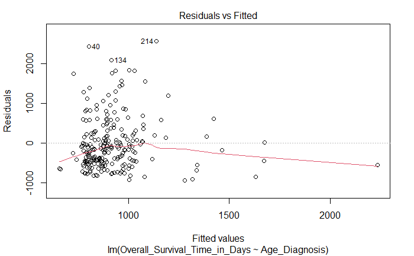

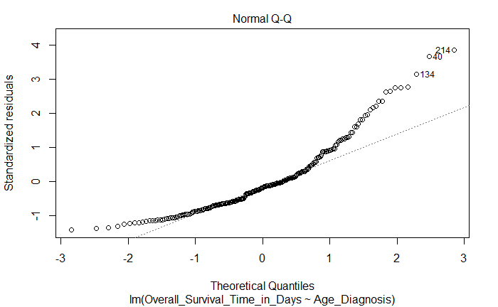

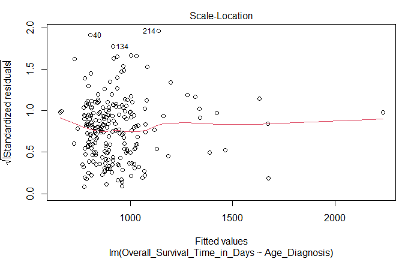

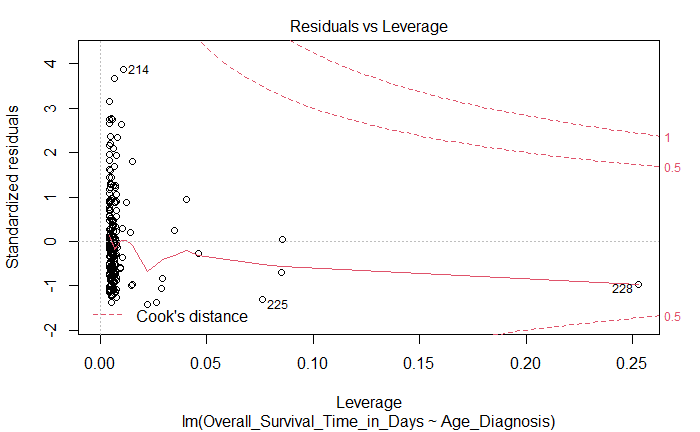

After running the model we get a p-value of less that 0.05 which means that there appears to be a correlation between the age of diagnosis and the survival time in days. We can also see how well the data fits the linear model by looking at the adjusted R-squared. You typically want this value to be as close to 1 as possible. Here the r-squared value is 0.061, which is very small meaning that a linear model is not necessarily a good model to use for this data. This is also suggested by the residuals plots failing to meet the conditions of a linear regression model.

Interpreting the plots of the linear model: (1) Residuals v. fitted: We expect a fairly horizontal red line which indicates that the data experiences a linear relationship. Clearly, there is not a very straigt line which means that our data might not be best represented with a linear model. (2) Normal Q-Q plot: Here we expcet the data to follow the straight dashed line, which would indicate that the residuals are normal. Our Q-Q plot shows that the residuals are fairly skewed, again implying that a linear model might not be the best fit for our data. The other two graphs, while they can help inform more about the fit of the linear model are not crucial for our analysis. The main focus is on the first two graphs analyzing the residuals of the linear model.

**(4) Do patients above and below the median age of diagnosis (18 mo) have different survival rates?**

The median age of diagnosis for neuroblastoma is 18 months old (~550 days) (Matthay, 2016). We want to explore whether being above or below the median age of diagnosis has a significant effect on survival rate. We have created two subsets of the dataframe including all neuroblastoma patients– one with patients diagnosed earlier than 18 months, and one including patients diagnosed later than 18 months. We used the table function sorted for vital status to see how many patients in each group were alive or dead. We first notice that the TARGET data has more patients diagnosed older than 18 mo which is inconsistent with the literature data and what we would expect from a random sample. This should be noted and flagged for potential sampling biases. Despite this, we see that a higher percentage of patients who are under the 18 mo threshold survive (~92%) compared to a much lower percentage of patients above the 18 mo threshold that survive (~41%).

```r
Less18<-filter(NBOnly, Age_Diagnosis<550)
Less18 <- as.data.frame(Less18) #Make data frame
table(Less18$Vital_Status)
Greater18<-filter(NBOnly, Age_Diagnosis>=550)
table(Greater18$Vital_Status)
Greater18 <- as.data.frame(Greater18) #Make data frame
```

```
Alive  Dead
   75     7
```

```
Alive  Dead
  153   221
```

To visualize the different survival rates between patients diagnosed above and below the median age of diagnosis, we can make bar graphs like we did to answer the first question. We can use the two data frames we created “Less18” and “Greater18” to make two bar graphs.

We can also use the function plot_grid() so that the ouput of the graphs show up together.

```r
#Plot for patients diagnosed below the median age
a <- ggplot(data=Less18, #Identify the data frame
       aes(x=Age_Diagnosis,y = Vital_Status, fill=Vital_Status)) + #Identify variables and fill=Vital_Status
  geom_bar(stat = "identity") + #Indicating we want the bar graph to show the vital status counts
  ggtitle("Vital status of patients diagnosed below the median age ") + #Title
  ylab("Vital Status") +
  xlab("Age at Diagnosis") +
  theme_cowplot()

#Plot for patients diagnosed after the median age
b <- ggplot(data=Greater18, #Identify the data frame
       aes(x=Age_Diagnosis,y = Vital_Status, fill=Vital_Status)) + #Identify variables and fill=Vital_Status
  geom_bar(stat = "identity") + #Indicating we want the bar graph to show the vital status counts
  ggtitle("Vital status of patients diagnosed above the median age ") + #Title
  ylab("Vital Status") +
  xlab("Age at Diagnosis") +
  theme_cowplot()

#Combining plots
plot_grid(a,b,nrow=2) #Indicate what plots to show and nrow= to show how many rows you want them in (could also use ncol= to indicate column numbers as well)
```

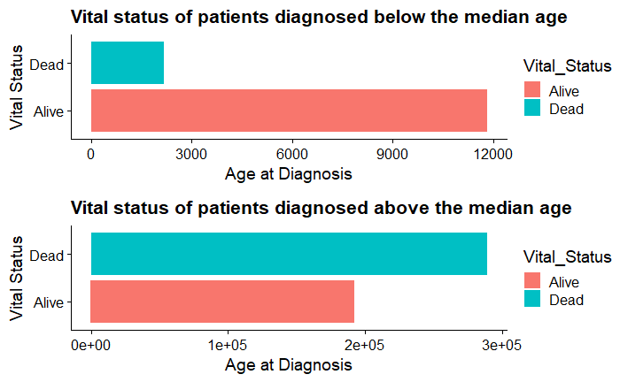

As we saw from the table, most of the patients diagnosed below the median age are Alive while most of the patients diagnosed after the median age are Dead.

To test whether the median age of diagnosis (18 mo) has a significant effect on the survival of neuroblastoma patients we want to compare the age of diagnosis to whether or not that patient survived. We want to test to see whether or not the two variables are independent of one another which we can do with a chi-squared test. The only assumptions are that the data is a simple random sample of the population, we are using two categorical variables, and have a large enough sample. We meet all of these criteria so we can run the test. To run this test, we can create a table that contains the two variables of interest (median age of diagnosis and their vital status). We can then run a chi squared test using the “chisq.test” function.

The null hypothesis we are testing is that the two variables (median age of diagnosis and their vital status) are independent of one another.

[output not shown]

There is a p-value of 3.088e-16, which is much less than 0.05, so we reject the null hypothesis and can see that the two variables are in fact dependent on one another.

# Acknowledgements

The TARGET dataset was produced by the lab of Dr. John Maris at The Children’s Hospital of Philadelphia (Jayne worked in this lab over the summer and was given permission to use the dataset for the project).

Background information on neuroblastoma: Matthay, K., Maris, J., Schleiermacher, G. et al. Neuroblastoma. Nat Rev Dis Primers 2, 16078 (2016). https://doi.org/10.1038/nrdp.2016.78

To help with the hypothesis testing section I used the following websites: https://data-flair.training/blogs/chi-square-test-in-r/ http://www.sthda.com/english/wiki/unpaired-two-samples-t-test-in-r https://www.datasciencemadesimple.com/delete-or-drop-rows-in-r-with-conditions-2/#:~:text=Drop%20Rows%20by%20row%20number,by%20the%20’%2D’%20operator.

Olivia worked mostly on the hypothesis testing section, Jayne worked mainly on the data exploration section and ReadMe portion, and Sarah worked mostly on the data visualization section. All code chunks are labeled –Explorations (Jayne), –Visualization (Sarah), or –Hypothesis (Olivia). All three of us went through and checked all of the code and annotations for errors once the project was complete.